# Example 2 — GC content around transcription start sites

## Installing the genome packages

Both BSgenome packages are ~500–900 MB and distributed via Bioconductor. They are usually pre-installed on classroom workstations — if not, install them once with `BiocManager`:

```r
if (!requireNamespace("BiocManager", quietly = TRUE))
  install.packages("BiocManager")

BiocManager::install(c(
  "BSgenome.Hsapiens.UCSC.hg38",     # human, ~900 MB
  "BSgenome.Drerio.UCSC.danRer11",   # zebrafish, ~450 MB
  "rtracklayer"                      # BED import
))
```

Check what’s already installed:

```r
requireNamespace("BSgenome.Hsapiens.UCSC.hg38", quietly = TRUE)
```

## Load libraries

```r
library(Biostrings)
library(BSgenome)
library(rtracklayer)
library(BSgenome.Hsapiens.UCSC.hg38)
library(BSgenome.Drerio.UCSC.danRer11)
library(ggplot2)
```

## The biological question

- Protein-coding genes in vertebrates are typically embedded in **GC-rich regions**, with the peak right at the transcription start site (TSS).
- That GC peak overlaps with **CpG islands** and correlates with:
  - open chromatin,
  - efficient mRNA nuclear export,
  - higher translation efficiency.
- Plan for this example:
  1. Extract ±1 kb windows around TSSs in **human** and **zebrafish**.
  2. Compute GC content in a 50 bp sliding window.
  3. Average across thousands of TSSs.
  4. Compare against the chromosome-wide GC baseline.

## Loading genomes as BSgenome objects

Unlike Example 1, we use **precompiled BSgenome packages** here — no FASTA parsing, no re-downloading, chromosomes loaded lazily from disk.

```r
BSgenome.Hsapiens.UCSC.hg38
```

```
| BSgenome object for Human
| - organism: Homo sapiens
| - provider: UCSC
| - genome: hg38
| - release date: 2023/01/31
| - 711 sequence(s):
|     chr1                    chr2                    chr3
|     chr4                    chr5                    chr6
|     chr7                    chr8                    chr9
|     chr10                   chr11                   chr12
|     chr13                   chr14                   chr15
|     ...                     ...                     ...
|     chr19_KV575256v1_alt    chr19_KV575257v1_alt    chr19_KV575258v1_alt
|     chr19_KV575259v1_alt    chr19_KV575260v1_alt    chr19_MU273387v1_alt
|     chr22_KN196485v1_alt    chr22_KN196486v1_alt    chr22_KQ458387v1_alt
|     chr22_KQ458388v1_alt    chr22_KQ759761v1_alt    chrX_KV766199v1_alt
|     chrX_MU273395v1_alt     chrX_MU273396v1_alt     chrX_MU273397v1_alt
| Tips: call 'seqnames()' on the object to get all the sequence names, call
| 'seqinfo()' to get the full sequence info, use the '$' or '[[' operator to
| access a given sequence, see '?BSgenome' for more information.
```

## Peeking at the genome object

```r
seqnames(BSgenome.Hsapiens.UCSC.hg38) |> head()
```

```
[1] "chr1" "chr2" "chr3" "chr4" "chr5" "chr6"
```

```r
seqlengths(BSgenome.Hsapiens.UCSC.hg38)["chr1"]
```

```
     chr1
248956422
```

- A BSgenome behaves like a **named collection of chromosomes**.
- Chromosome sequences are read from disk only when accessed — large genomes take very little RAM until you actually touch them.

## Importing BED files with rtracklayer

The TSS coordinates were pre-computed and saved as BED. Each row is a ±1 kb window centered on a TSS → width = 2001 bp.

```r
hsapiens_bed_path <- "../../data/seq_data/tss_hs.bed"
drerio_bed_path   <- "../../data/seq_data/tss_drerio.bed"

hs_bed     <- import(hsapiens_bed_path, format = "BED")
drerio_bed <- import(drerio_bed_path,   format = "BED")

length(hs_bed)
```

```
[1] 320877
```

```r
width(hs_bed)[1:5]
```

```
[1] 2001 2001 2001 2001 2001
```

```r
hs_bed
```

```
GRanges object with 320877 ranges and 2 metadata columns:
           seqnames        ranges strand |        name     score
              <Rle>     <IRanges>  <Rle> | <character> <numeric>
       [1]        Y 385907-387907      - |        <NA>         0
       [2]        Y 340711-342711      - |        <NA>         0
       [3]        Y 346324-348324      - |        <NA>         0
       [4]        Y 344629-346629      - |        <NA>         0
       [5]        Y 344626-346626      - |        <NA>         0
       ...      ...           ...    ... .         ...       ...
  [320873]        1 180200-182200      - |        <NA>         0
  [320874]        1 119932-121932      - |        <NA>         0
  [320875]        1 128217-130217      - |        <NA>         0
  [320876]        1 128173-130173      - |        <NA>         0
  [320877]        1 132566-134566      - |        <NA>         0
  -------
  seqinfo: 24 sequences from an unspecified genome; no seqlengths
```

## Aligning seqnames — the “chr” prefix problem

A very common pitfall:

- BED / Ensembl style → `"1"`, `"2"`, `"X"`, `"Y"`
- UCSC / BSgenome style → `"chr1"`, `"chr2"`, `"chrX"`, `"chrY"`

`getSeq()` fails or returns nothing when the names don’t match **exactly**.

```r
seqlevels(hs_bed) |> head()
```

```
[1] "Y"  "13" "21" "18" "20" "22"
```

```r
seqlevels(BSgenome.Hsapiens.UCSC.hg38) |> head()
```

```
[1] "chr1" "chr2" "chr3" "chr4" "chr5" "chr6"
```

## Fixing the seqnames

```r
seqlevels(hs_bed)     <- paste0("chr", seqlevels(hs_bed))
seqlevels(drerio_bed) <- paste0("chr", seqlevels(drerio_bed))

seqlevels(hs_bed) |> head()
```

```
[1] "chrY"  "chr13" "chr21" "chr18" "chr20" "chr22"
```

Now both objects use the same naming convention — `getSeq()` will work.

## Extracting sequences with `getSeq()`

`getSeq(genome, ranges)` returns a `DNAStringSet`, one sequence per range. Strand is respected — minus-strand ranges are **reverse-complemented** automatically.

```r
hs_sequences     <- getSeq(BSgenome.Hsapiens.UCSC.hg38, hs_bed)
drerio_sequences <- getSeq(BSgenome.Drerio.UCSC.danRer11, drerio_bed)

hs_sequences
```

```
DNAStringSet object of length 320877:
         width seq
     [1]  2001 TTACTTATTGAGTCTGGCTCGATTTATGCAG...GGCTGATGTTGTATTTTTAGTAGAGACTGGG
     [2]  2001 GGTCTCACTCCCGCCTCCCGTTGGCGAGGTC...CCAGGGTGAGGGGACGGACGGGCGAGAGGAC
     [3]  2001 GGATTACAGGCATGAGCCACCACGCCCAGCC...CAAGGGCGCGCCCCTCTCCCGGCTCCCGGTC
     [4]  2001 CTTCTGCGGACGGGGCGGGCGGGGCCCGGGG...AGCGCCGGCCCGTGTGGCCTGGGCCAGCACC
     [5]  2001 CTGCGGACGGGGCGGGCGGGGCCCGGGGTTC...GCCGGCCCGTGTGGCCTGGGCCAGCACCTGC
     ...   ... ...
[320873]  2001 AGGGCTTCACCTGTTAGACTGGCAAAAATCC...AGGGTAAGGATTAGGGTTAGGATTAGGGTAA
[320874]  2001 GCTTTGTACTGGGAGGAGGGCGTGAAGGGCT...AATTCAATACATGCCTACTGATATGGTTAGG
[320875]  2001 AACCTCCGCTTCCTGGGTTCAAGCGATTCTC...TAGTTTTTATGATAAAAGGTTGGATTTTGAT
[320876]  2001 CCAAGTAGCTGGGACTACAGGTGTGTGCCAC...ATTTTGTGTCAGAATTAAAACTGGTATTAGA
[320877]  2001 CGCCTCCCTGTGGCCCAAGGCCCTCTTCACA...AGGTGGATCGGGGGACCCTGGGGGCTCAGGA
```

## `letterFrequencyInSlidingView()`

For a single sequence and a window of width `W`:

- slides a window of width `W` across the sequence,
- returns, for each window position, the count of the requested letters.

Output is a matrix with `length(seq) − W + 1` rows, one column per letter set.

```r
n <- 5000
x <- sapply(sample(hs_sequences, n), function(seq) {
  letterFrequencyInSlidingView(seq, view.width = 50, letters = "GC")
})
dim(x)   # rows = window positions, cols = sampled TSSs
```

```
[1] 1952 5000
```

## Average GC profile around human TSS

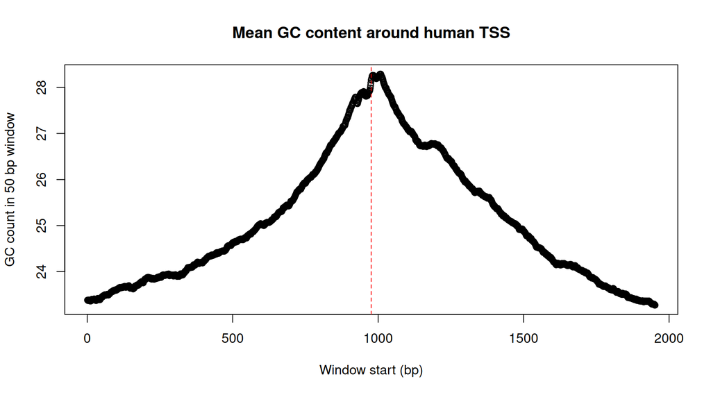

```r
gc_mean_content <- rowMeans(x, na.rm = TRUE)
plot(gc_mean_content,
     xlab = "Window start (bp)",
     ylab = "GC count in 50 bp window",
     main = "Mean GC content around human TSS")
n_windows <- length(gc_mean_content)
abline(v = n_windows / 2, col = "red", lty = 2)
```

The peak sits right at the TSS — exactly where we expected.

## A reusable profile function

The same logic works for any letter set (GC, AT, CG, single bases) and any window width. Wrap it up once, reuse it everywhere.

```r
get_N_profile <- function(s, W = 50, letters = "GC", sample_size = 5000) {
  x <- sapply(sample(s, sample_size), function(seq) {
    letterFrequencyInSlidingView(seq, view.width = W, letters = letters)
  })
  mean_content <- rowMeans(x, na.rm = TRUE)
  mean_content / W          # normalise to a per-base proportion in [0, 1]
}

hs_gc_profile <- get_N_profile(hs_sequences,     W = 50, letters = "GC")
dr_gc_profile <- get_N_profile(drerio_sequences, W = 50, letters = "GC")
```

> 📝 **Task 1** — compute separate A, T, G, and C profiles for the human set and overlay them. Which bases drive the peak at the TSS?

## Comparing species with base R

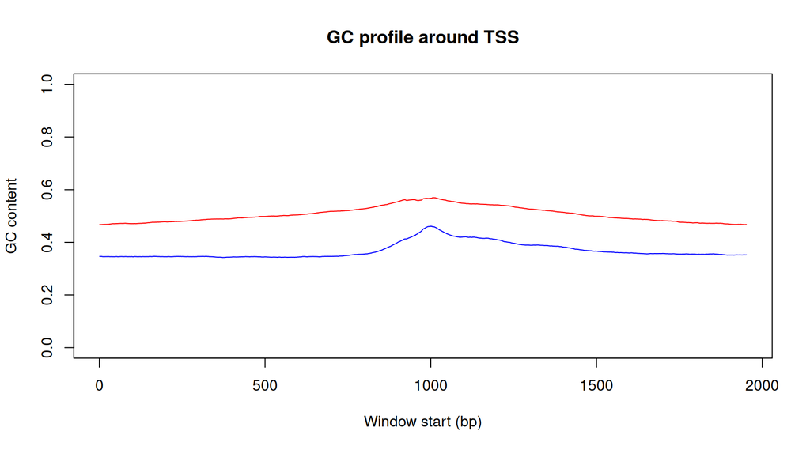

```r
plot(dr_gc_profile, type = "l", col = "blue", ylim = c(0, 1),
     xlab = "Window start (bp)", ylab = "GC content",
     main = "GC profile around TSS")
points(hs_gc_profile, type = "l", col = "red")
```

## Genome-wide GC baseline

Is the TSS peak really unusual? We need a reference — the chromosome-wide GC content, measured once on chr1 of each species.

```r
gc_hs_chr1 <- letterFrequency(BSgenome.Hsapiens.UCSC.hg38$chr1,
                              letters = "GC", as.prob = TRUE)
gc_dr_chr1 <- letterFrequency(BSgenome.Drerio.UCSC.danRer11$chr1,
                              letters = "GC", as.prob = TRUE)

cat("Human   chr1 GC:", round(gc_hs_chr1, 3), "\n")
```

```
Human   chr1 GC: 0.386
```

```r
cat("Zebrafish chr1 GC:", round(gc_dr_chr1, 3), "\n")
```

```
Zebrafish chr1 GC: 0.364
```

Both TSS peaks sit well above each species’ own genome-wide baseline.

## Baselines on the plot

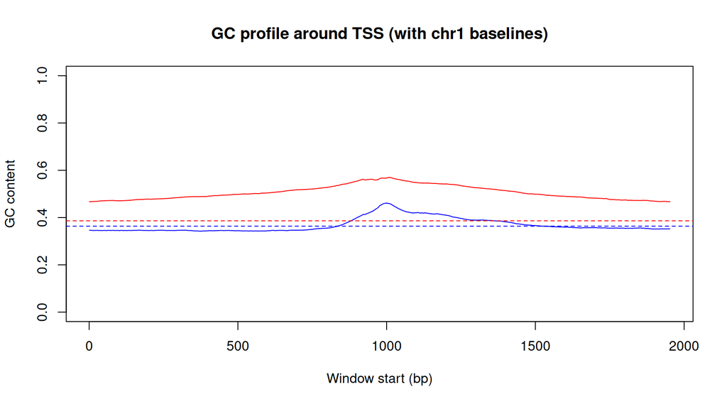

```r
plot(dr_gc_profile, type = "l", col = "blue", ylim = c(0, 1),
     xlab = "Window start (bp)", ylab = "GC content",
     main = "GC profile around TSS (with chr1 baselines)")
points(hs_gc_profile, type = "l", col = "red")
abline(h = gc_hs_chr1, col = "red",  lty = 2)
abline(h = gc_dr_chr1, col = "blue", lty = 2)
```

## The same figure with ggplot2 — code

```r
gc_profile_df <- data.frame(
  Position   = 1:length(hs_gc_profile),
  GC_Content = c(hs_gc_profile, dr_gc_profile),
  Species    = rep(c("Human", "Zebrafish"), each = length(hs_gc_profile))
)

p <- ggplot(gc_profile_df, aes(x = Position, y = GC_Content, color = Species)) +
  geom_line() +
  scale_color_manual(values = c("Human" = "red", "Zebrafish" = "blue")) +
  geom_hline(yintercept = gc_hs_chr1, color = "red",  linetype = "dashed") +
  geom_hline(yintercept = gc_dr_chr1, color = "blue", linetype = "dashed") +
  labs(title = "GC content profile around TSS",
       subtitle = "Dashed lines: chromosome-1 GC baseline per species",
       x = "Position relative to TSS (bp)",
       y = "Mean GC content") +
  theme_minimal() +
  theme(legend.position = "top")
```

## The same figure with ggplot2 — plot

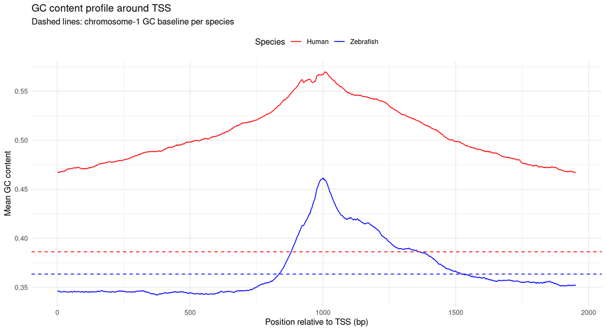

> 📝 **Task 2** — rescale the x-axis so the TSS sits at 0 and the axis runs from roughly -1000 to +1000 bp.

## Summary

- **BSgenome packages** make whole genomes available as lazily-loaded R objects.
- **`import()`** from rtracklayer reads BED / GFF / BigWig into `GRanges`.
- Seqname conventions differ — always align them before `getSeq()`.
- **`getSeq()`** extracts sequences by `GRanges`, respecting strand.
- **`letterFrequencyInSlidingView()`** computes per-position letter counts along a sequence.
- Wrapping the pipeline into a function (`get_N_profile()`) makes the same analysis reusable for any letter set, window, and species.

Final exercise: repeat with `letters = "CG"` to build a CpG profile — expect a much sharper peak than GC.